# Predictive Modeling of Feedback Type Based on Neural Activity and Visual Stimuli in Mice

Kaushal Ramalingam

2024-03-18

### Abstract:

This study leverages neural activity data and visual stimuli information to predict feedback types in mouse decision-making processes, as per the experiments conducted by Steinmetz et al. (2019). We analyzed neural spike train data across 18 sessions from four mice to understand the correlation between visual cortex activity, stimulus contrast, and behavioral outcomes. Data preprocessing involved normalization of spike counts and extraction of relevant features, followed by k-means clustering to uncover patterns in neuronal firing related to the experimental conditions. A predictive model using logistic regression was then developed, incorporating cluster assignments and stimulus contrasts as explanatory variables. The model was evaluated using accuracy metrics and a confusion matrix on a held-out test set. Preliminary results indicate a nuanced relationship between neural activity and decision-making feedback, underscoring the complexity of neuronal encoding in sensory-driven behaviors. This report details the methodologies employed, discusses the findings in the context of neuroscientific inquiry, and highlights potential avenues for future research to build upon the established groundwork.

### Introduction:

The intricate relationship between neural activity and behavior forms the cornerstone of neuroscience. Recent advances have allowed for detailed recording and analysis of neural firing patterns, particularly in model organisms such as mice during behavioral tasks. The landmark study by Steinmetz et al. (2019) has been instrumental in providing a comprehensive dataset of neural activity from the visual cortex during a controlled decision-making process. The primary goal of this research is to decode the neuronal underpinnings that drive visual stimulus-based decision-making in mice.

Understanding how the brain interprets and responds to varying levels of visual stimuli is fundamental to elucidating the broader principles of sensory processing and neural computation. In this context, the ability to predict behavioral outcomes—categorized as feedback types—based on neural spike train data offers a window into the cognitive mechanisms at play. Our study focuses on analyzing neural activity patterns across multiple sessions, involving several mice, to build a predictive framework that correlates with the given feedback types.

The intricacies of this task involve parsing through complex, high-dimensional spike train data to discern patterns that are predictive of decision outcomes. Our approach integrates data preprocessing, feature extraction, clustering analysis, and predictive modeling to establish a link between the observed neuronal activity and the resultant feedback types. Through these methods, we aim to contribute to the existing body of knowledge by offering insights into how certain neural activity patterns may influence or predict decision-making behaviors in mice.

This report outlines the process from initial data exploration to model development and validation. By dissecting the neural patterns receptive to visual stimuli and their association with behavioral feedback, we try to understand the predictive capacity of neural activity and our perception of sensory-driven decision-making processes in the brain.

### Exploratory Data Analysis (EDA):

First, we are exploring the structure of the data we are presented with. Each session has 8 variables: contrast_left (left contrast value), contrast_right (right contrast value), feedback_type(whether mouse response was success or failure), mouse_name (name of the mouse experimented on), brain_area (region of the brain the neuron resides), date_exp (experimentation date), spks(neuron spikes), and time (time bins of trial). We see that in Session 7 trial 11, left_contrast value is 0, right_contrast value is 0 and feedback_type is -1 (failure). We also see a matrix of brain areas for each neuron in the session, indicating the diversity of brain regions stimulated during the trials.

```
## [1] "contrast_left"  "contrast_right" "feedback_type"  "mouse_name"
## [5] "brain_area"     "date_exp"       "spks"           "time"
```

```
## [1] "2017-11-05"
```

```
## [1] 0
```

```
## [1] 0
```

```
## [1] -1
```

```
##   [1] "VPL"  "root" "CA3"  "VPL"  "VPL"  "root" "CA3"  "VPL"  "CA3"  "root"
##  [11] "CA3"  "CA3"  "CA3"  "root" "CA3"  "CA3"  "CA3"  "root" "VPL"  "VPL"
##  [21] "root" "CA3"  "VPL"  "CA3"  "root" "CA3"  "CA3"  "root" "root" "CA3"
##  [31] "root" "root" "VPL"  "root" "VPL"  "root" "VPL"  "root" "VPL"  "CA3"
##  [41] "LD"   "root" "VPL"  "VPL"  "VPL"  "root" "CA3"  "CA3"  "CA3"  "CA3"
##  [51] "CA3"  "CA3"  "CA3"  "VPL"  "root" "CA3"  "CA3"  "CA3"  "VPL"  "VPL"
##  [61] "root" "root" "LD"   "CA3"  "root" "VPL"  "VPL"  "VPL"  "CA3"  "VPL"
##  [71] "VPL"  "VPL"  "root" "CA3"  "CA3"  "root" "VPL"  "root" "root" "VPL"
##  [81] "CA3"  "CA3"  "VPL"  "CA3"  "CA3"  "LD"   "VPL"  "VPL"  "CA3"  "CA3"
##  [91] "CA3"  "LD"   "CA3"  "CA3"  "CA3"  "root" "root" "root" "CA3"  "CA3"
## [101] "CA3"  "CA3"  "VPL"  "root" "CA3"  "VPL"  "LD"   "CA3"  "VPL"  "CA3"
## [111] "LD"   "LD"   "VPL"  "VPL"  "CA3"  "root" "VPL"  "root" "VPL"  "VPL"
## [121] "root" "CA3"  "CA3"  "CA3"  "CA3"  "root" "VPL"  "CA3"  "CA3"  "VPL"
## [131] "root" "CA3"  "root" "CA3"  "root" "VPL"  "VPL"  "VPL"  "CA3"  "VPL"
## [141] "VPL"  "VPL"  "root" "VPL"  "VPL"  "CA3"  "LD"   "CA3"  "CA3"  "LD"
```

[output cut: 44 more lines]

#### Figure 1:

| mouse_name | n_brain_area | n_neurons | n_trials | success_rate |
| --- | --- | --- | --- | --- |
| Cori | 8 | 734 | 114 | 0.605 |
| Cori | 5 | 1070 | 251 | 0.633 |
| Cori | 11 | 619 | 228 | 0.662 |
| Forssmann | 11 | 1769 | 249 | 0.667 |
| Forssmann | 10 | 1077 | 254 | 0.661 |
| Forssmann | 5 | 1169 | 290 | 0.741 |
| Forssmann | 8 | 584 | 252 | 0.671 |
| Hench | 15 | 1157 | 250 | 0.644 |
| Hench | 12 | 788 | 372 | 0.685 |
| Hench | 13 | 1172 | 447 | 0.620 |
| Hench | 6 | 857 | 342 | 0.795 |
| Lederberg | 12 | 698 | 340 | 0.738 |
| Lederberg | 15 | 983 | 300 | 0.797 |
| Lederberg | 10 | 756 | 268 | 0.694 |
| Lederberg | 8 | 743 | 404 | 0.765 |
| Lederberg | 6 | 474 | 280 | 0.718 |
| Lederberg | 6 | 565 | 224 | 0.830 |
| Lederberg | 10 | 1090 | 216 | 0.806 |

*Figure 1 depicts summarized trial information regarding each of the 18 sessions. Mouse name, total brain regions activated, neurons activated, number of trials, and success rate computed by dividing number of successes by total number of trials are depicted for each session. This graph shows heterogeneity between sessions: each session contains a varying number of trials, neurons fired and brain areas, but more importantly varying success rates of experimentation.

#### Figure 2:

```
## # A tibble: 49,173 × 13
##    brain_area region_sum_spike region_count region_mean_spike trail_id
##    <chr>                 <dbl>        <int>             <dbl>    <int>
##  1 ACA                     138          109             1.27         1
##  2 CA3                     104           68             1.53         1
##  3 DG                       79           34             2.32         1
##  4 LS                      269          139             1.94         1
##  5 MOs                     106          113             0.938        1
##  6 SUB                     156           75             2.08         1
##  7 VISp                    300          178             1.69         1
##  8 root                      9           18             0.5          1
##  9 ACA                      64          109             0.587        2
## 10 CA3                     116           68             1.71         2
## # ℹ 49,163 more rows
## # ℹ 8 more variables: contrast_left <dbl>, contrast_right <dbl>,
## #   feedback_type <dbl>, mouse_name <chr>, date_exp <chr>, session_id <int>,
## #   success <dbl>, contrast_diff <dbl>
```

*Figure 2: We define two functions, get_trail_data and get_session_data, and then iterate through session IDs to aggregate data into a single tibble (full_tibble) that displays summarized neuron spike data by brain area for each trial, including the total spikes (region_sum_spike), the number of neurons (region_count), and the average spikes per neuron (region_mean_spike) within each brain area. It also displays trial metadata (much of which is displayed in Figure 1) along with columns like success (binary indicator derived from feedback_type, marking whether the trial was successful (1) or not (0)) and contrast_diff (the absolute difference between the contrast_left and contrast_right values, indicating the level of contrast disparity presented during the trial).

#### Figure 3:

```
##    brain_area successes
## 1         ACA       893
## 2         CA3      1338
## 3          DG      1482
## 4          LS        69
## 5         MOs      1240
## 6         SUB       815
## 7        VISp      1261
## 8        root      3241
## 9         CA1      2228
## 10       POST       587
## 11       VISl       691
## 12      VISpm       159
## 13         LP       312
## 14         MG       151
```

[output cut: 48 more lines]

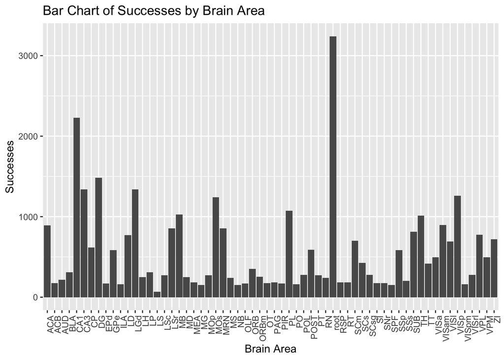

#### Figure 4:

```
##    brain_area successes region_success_rate
## 1         ACA       893           6.4710145
## 2         CA3      1338          12.8653846
## 3          DG      1482          18.7594937
## 4          LS        69           0.2565056
## 5         MOs      1240          11.6981132
## 6         SUB       815           5.2243590
## 7        VISp      1261           4.2033333
## 8        root      3241         360.1111111
## 9         CA1      2228          10.4600939
## 10       POST       587           1.6916427
## 11       VISl       691           2.1393189
## 12      VISpm       159           0.2632450
## 13         LP       312          17.3333333
## 14         MG       151           0.4048257
```

[output cut: 48 more lines]

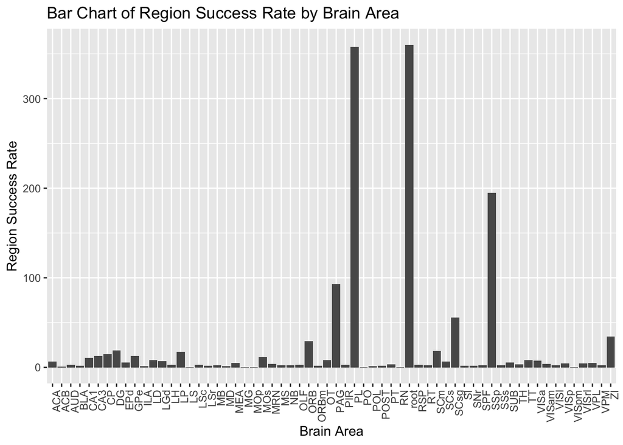

Figure 4: Figure 4 depicts brain area on the x-axis and brain area success rate on the y-axis. We can see that particular brain areas like PL, root, and SSp achieve distinctly higher success rates than the rest of the brain areas on the plot. By plotting brain area success rate and not total success on the y-axis, we correct for the discrepancies in interpretation from Figure 3.

My findings during the EDA process pushed me to inquire further if brain area had a significant impact on neural spikes, and specifically on success rate in predicting feedback type. Using the information collected about heterogeneity and brain area, I proceeded to use clustering for the next steps to try to isolate similar groups of spikes.

### Data Integration:

We wanted to test if k-means clustering can be performed to analyze the relationship between neural spike data and feedback type as a technique to reduce the complexity of our heterogenous data.

#### Figure 5:

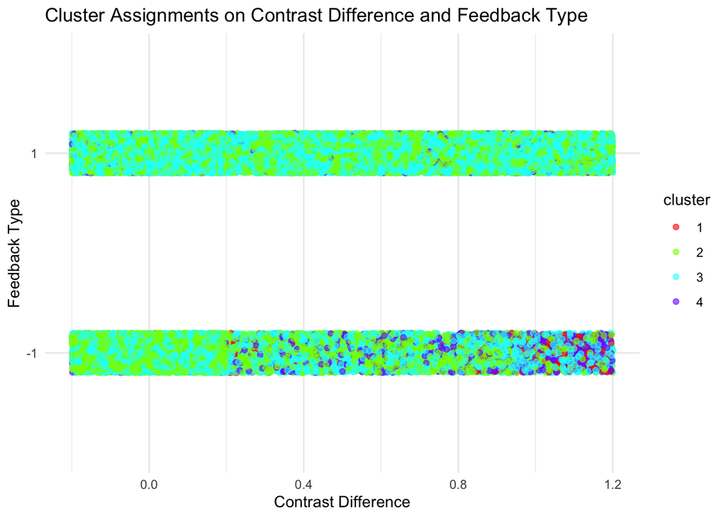

*Figure 5: The scatter plot above illustrates the results of a k-means clustering algorithm applied to our neural activity dataset. The clustering is based on the average neural activity (mean spike count) across brain regions for each trial, with the data points representing individual trials colored according to their assigned cluster.

##### Interpretation of Clusters:

Clustering Variables: The k-means algorithm clustered the trials based on the mean neural activity (region_mean_spike) within each brain area, which is a proxy for the neurons’ response to visual stimuli. Each cluster represents a group of trials with similar patterns of neural activity.

Cluster Distribution: The horizontal bands suggest that the Feedback Type is binary, representing successful (1) and unsuccessful (-1) trials, which makes sense considering the context of our analysis. The distribution of clusters along the Contrast Difference axis indicates that this variable alone does not segregate the clusters, implying that the clustering is primarily informed by the similarity in neural response patterns rather than the stimulus contrast per se. However, for the purposes of this analysis, we will move forward with these clusters as a means of integration into our prediction model to see if these clusters can more accurately predict feedback_type.

### Predictive Modeling:

The predictors in our model are as follows:

Cluster: This variable represents the cluster assignments obtained from the k-means clustering algorithm. Each trial is assigned to a specific cluster based on its neural activity patterns. The cluster variable serves as a categorical predictor in the logistic regression model.

Contrast_left & Contrast_right: variables provided in the session data

Ultimately, the decision to utilize a logistic regresson model was reached. Many factors were considered in this approach, especially when predicting a binary outcome like feedback_type:

1. Logistic regression provides interpretable results. The coefficients estimated by the model represent the log odds of the outcome variable. This allows for easy interpretation of how each predictor influences the likelihood of success or failure.
2. Logistic regression can handle irrelevant predictors or predictors that do not influence the outcome variable well. It tends to give low weights to such predictors, effectively ignoring them in the model.
3. Logistic regression is computationally efficient, making it suitable for large datasets with a binary outcome like the one we are working with.

```
##
## Call:
## glm(formula = feedback_type ~ cluster + contrast_diff + contrast_left +
##     contrast_right, family = binomial, data = train_data)
##
## Deviance Residuals:
##     Min       1Q   Median       3Q      Max
## -1.9792  -1.3986   0.7446   0.8648   1.8459
##
## Coefficients:
##                Estimate Std. Error z value Pr(>|z|)
## (Intercept)    -1.50288    0.13001  -11.56  < 2e-16 ***
## cluster2        2.29384    0.13001   17.64  < 2e-16 ***
## cluster3        2.09883    0.12990   16.16  < 2e-16 ***
## cluster4        1.45282    0.13681   10.62  < 2e-16 ***
## contrast_diff   1.28359    0.04030   31.85  < 2e-16 ***
## contrast_left  -0.26805    0.03363   -7.97 1.58e-15 ***
## contrast_right -0.59740    0.03423  -17.45  < 2e-16 ***
## ---
## Signif. codes:  0 '***' 0.001 '**' 0.01 '*' 0.05 '.' 0.1 ' ' 1
##
## (Dispersion parameter for binomial family taken to be 1)
##
##     Null deviance: 47762  on 39338  degrees of freedom
## Residual deviance: 46143  on 39332  degrees of freedom
## AIC: 46157
##
## Number of Fisher Scoring iterations: 4
```

```
##          Actual
## Predicted   -1    1
##         0  198  231
##         1 2708 6697
```

```
## [1] "Accuracy: 0.701138905836892"
```

Initial split test data results: Our logistic model was found to have a 70.11% accuracy rate given the predictors used, indicating moderately good predictive capability.

### Prediction performance on the test sets:

```
##          Actual
## Predicted  -1   1
##         0  88 104
##         1 272 448
```

```
## [1] "Accuracy on Test 1 Data: 0.587719298245614"
```

```
## [1] "AUC for Test 1 Data: 0.73719806763285"
```

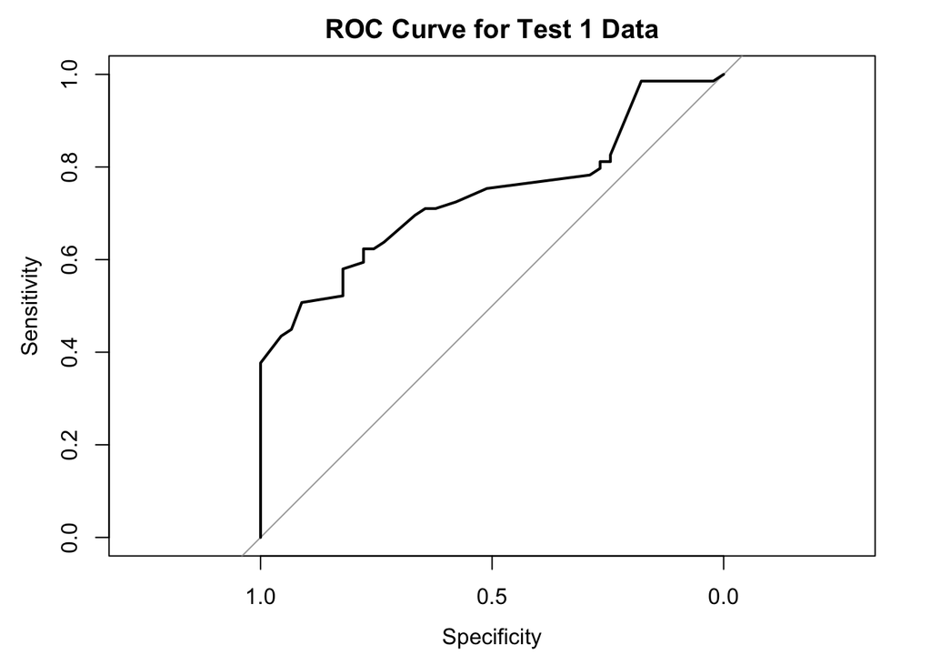

```
##          Actual
## Predicted  -1   1
##         0  90 160
##         1 370 635
```

```
## [1] "Accuracy on Test 2 Data: 0.577689243027888"
```

```
## [1] "AUC for Test 1 Data: 0.577864369701941"
```

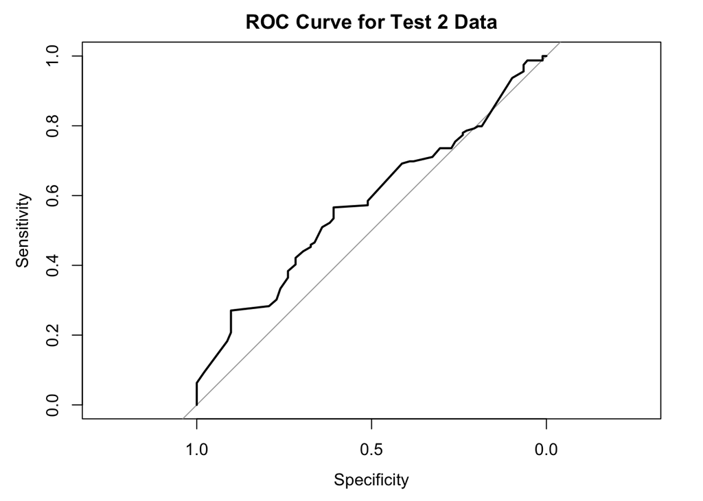

The ROC curves for Test 1 and 2 Data indicate predictive capability of the model, although the curve is not situated as far to the top left corner as we would have wanted (indicating higher True Postive & Negative Rates).

### Discussion:

Through this project we aimed to build a predictive model to forecast the outcome of each trial based on neural activity data and stimulus features. Our analysis focused on understanding the impact of various predictors on the logistic regression model’s performance.

However, while our initial model showed promising results, there is still ample room for improvement. The average accuracy between test sets 1 and 2 came to be 58.27%, which was well below industry standards and disappointingly only slightly better than a case of the model guessing with a 50/50 chance. However, considering this was my first time building a prediction model from scratch, I view this as a major accomplishment in my experience with data analysis and machine learning. In future endeavors, we intend to explore additional data integration methods to incorporate more predictors and enhance the model’s accuracy further. Potential avenues include leveraging advanced feature engineering techniques, exploring alternative machine learning algorithms beyond logistic regression, and incorporating domain-specific knowledge to refine the model’s performance.

By expanding our analysis to include a broader range of predictors and adopting more sophisticated modeling approaches, we aim to develop a more robust predictive model capable of accurately forecasting trial outcomes. Ultimately, such advancements hold the potential to deepen our understanding of neural processes underlying decision-making tasks and contribute to advancements in neuroscience research.

### References:

ChatGPT - Utilized for assistance with section writeups and data integration

##### Github Repo for Source Code: https://github.com/kaushalrrr/NeuralActivityProject